# scRNA-seq: Individual cell labeling

Steven Foltz and Jaclyn Taroni

2024

This notebook uses pair-based medulloblastoma subgroup prediction models trained on bulk data to predict the subgroup of individual cells in scRNA-seq samples. k-Top Scoring Pairs (kTSP) and random forest (RF) models were trained using bulk gene expression data (bulk array and RNA-seq) in `analysis_notebooks/baseline_models.Rmd`. Here, we analyze the kTSP and RF predictions on individual cells generated in `predict/predict_pseudobulk_and_single_cells.R`.

We are using scRNA-seq data associated with the following publications:

- [Hovestadt, et al.](https://www.nature.com/articles/s41586-019-1434-6), which is Smart-seq2 dataset
- [Riemondy, et al.](https://doi.org/10.1093/neuonc/noab135), which is a 10X Genomics dataset

# Setup

Set seed.

```r
set.seed(8222)
```

Set MB subgroups.

```r
mb_subgroups <- c("G3", "G4", "SHH", "WNT")
```

## Libraries and functions

```r
# Source color scheme
source(here::here("utils/color_schemes.R"))

# Load libraries
library(ggplot2)
library(patchwork)
library(SingleCellExperiment)
```

## Directories and files

### Input

```r
results_dir <- here::here("results")
processed_data_dir <- here::here("processed_data")
single_cell_data_dir <- here::here(processed_data_dir, "single_cell")
smartseq_data_dir <- here::here(single_cell_data_dir, "GSE119926")
tenx_data_dir <- here::here(single_cell_data_dir, "GSE155446")
plots_dir <- here::here("plots")
plots_data_dir <- here::here(plots_dir, "data")
models_dir <- here::here("models")

# Get file paths of individual SingleCellExperiment RDS objects
sce_files <- c(fs::dir_ls(path = fs::path(smartseq_data_dir,
                                          "sce"),
                          glob = "*_sce.rds"),
               fs::dir_ls(path = fs::path(tenx_data_dir,
                                          "sce"),
                          glob = "*_sce.rds")
)
# Extract sample titles from the file names
sce_sample_titles <- stringr::word(names(sce_files), start = -1, sep = "/") |>
  stringr::str_remove_all("\\_sce.rds")

# Fail if there are any sample title collisions
if (any(duplicated(sce_sample_titles))) {

  stop("Duplicate single-cell sample title detected!")

} else {

  # Name the vector using the sample title
  names(sce_files) <- sce_sample_titles

}

# Genes in official weighted models
genes_filepath <- file.path(results_dir,
                            "genes_in_kTSP_unw_and_RF_w_official_models.tsv")

# Individual cell predictions plot data
plot_data_filepath <- here::here(plots_data_dir,
                                 "single_cell_test_predictions.tsv")

# We need the kTSP model for a later step
baseline_models_filepath <- here::here(models_dir,
                                      "baseline.rds")
```

## Read in data

### Predicted labels

Starting with the individual cells predicted labels plot data

```r
single_cell_plot_df <- readr::read_tsv(plot_data_filepath,
                                       show_col_types = FALSE)
```

### kTSP model

We need this – and only this – model for a later binary kTSP plot.

```r
baseline_models <- readr::read_rds(baseline_models_filepath)
official_model <- which(purrr::map_lgl(baseline_models, \(x) x[["official_model"]]))
ktsp_model <- baseline_models[[official_model]]$ktsp_unweighted$classifier
rm(baseline_models, official_model)
```

### Genes in models

Get the genes included in models

```r
genes_df <- readr::read_tsv(genes_filepath)
# Grab a vector of unique Ensembl gene identifiers
genes_vector <- genes_df |>
  dplyr::pull(gene) |>
  unique()
```

### SCE Expression

```r
sce_expression_list <- sce_files |>
  purrr::imap(
    \(x, sample_name) {

      # Read in SingleCellExperiment object
      sce <- readr::read_rds(x)

      # Append sample name to cell index -- cell index is used in the
      # data frame that has individual cell subgroup labels in it
      colnames(sce) <- stringr::str_c(sample_name,
                                      "_",
                                      1:ncol(sce))

      # Total number of genes detected
      num_genes_detected <- apply(counts(sce), 2, \(y) sum(y > 0))

      # Extract the expression values in the counts slot, for the genes included
      # in at least one model
      genex_df <- counts(sce)[which(rownames(sce) %in% genes_vector), ]

      # Return a list of:
      #   Counts or TPM (depending on the experiment) for genes in at
      #     least one model
      #   Number of genes that are detected in each cell
      list(genex_df = genex_df |>
             tibble::rownames_to_column("gene"),
           num_genes_detected = num_genes_detected)
    }
  )

# Create a long version of expression data frame with columns that include
# sample identifiers and cell indexes for joining with the plot data that
# contains predicted labels for each model and the study. We will also add the
# information about genes used in the models.
expression_df <- sce_expression_list |>
  purrr::map(\(x) x[["genex_df"]]) |>
  purrr::reduce(dplyr::inner_join, by = "gene") |>
  tidyr::pivot_longer(cols = -1,
                      names_to = "cell",
                      values_to = "expression") |>
  tidyr::separate(cell,
                  into = c("sample_accession", "cell_index"),
                  sep = "_") |>
  dplyr::mutate(cell_index = as.integer(cell_index)) |>
  dplyr::left_join(
    dplyr::select(single_cell_plot_df,
                  sample_accession,
                  cell_index,
                  predicted_labels,
                  model_type,
                  study
    ),
    by = c("sample_accession", "cell_index")
  ) |>
  dplyr::right_join(
    genes_df,
    by = "gene"
  )
# Get number of genes detected per cell and join with labels, other metadata
num_genes_detected_df <- sce_expression_list |>
  purrr::map(\(x) data.frame(
    num_genes_detected = x[["num_genes_detected"]]
  )) |>
  dplyr::bind_rows() |>
  tibble::rownames_to_column("cell_identifier") |>
  tidyr::separate(cell_identifier,
                  into = c("sample_accession", "cell_index"),
                  sep = "_") |>
  dplyr::mutate(cell_index = as.integer(cell_index)) |>
  dplyr::left_join(
    single_cell_plot_df |>
      dplyr::select(sample_accession,
                    cell_index,
                    study,
                    predicted_labels,
                    subgroup,
                    model_type),
    by = c("sample_accession", "cell_index")
  ) |>
  # A cell will be correctly classified when the predicted label matches the
  # true subgroup
  dplyr::mutate(correct_classification = (predicted_labels == subgroup))
```

## Plotting

### Individual cell predicted labels

Plot what proportion of individual cells are predicted to be each subgroup, keeping studies separate.

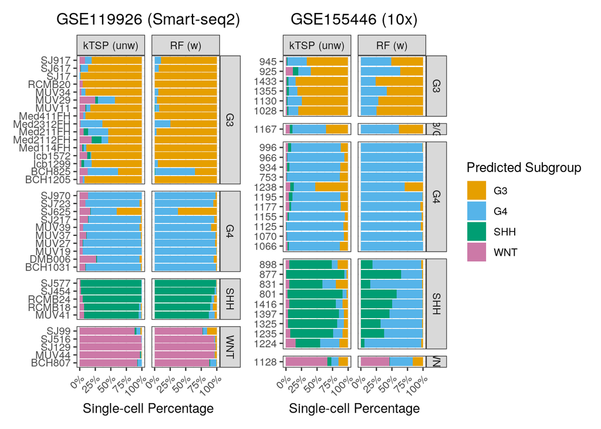

```r
smartseq_object <- single_cell_plot_df |>
  dplyr::filter(study == "GSE119926") |>
  dplyr::count(sample_accession, subgroup, predicted_labels, model_type) |>
  ggplot(aes(y = sample_accession,
             x = n,
             fill = predicted_labels)) +
  geom_col(position = position_fill()) +
  scale_x_continuous(labels = scales::percent) + # percentage makes sense here
  facet_grid(rows = vars(subgroup),
             cols = vars(model_type),
             space = "free_y",
             scales = "free_y") +
  scale_fill_manual(values = subgroup_colors) +
  labs(y = NULL,
       x = "Single-cell Percentage",
       fill = "Predicted Subgroup",
       title = "GSE119926 (Smart-seq2)") +
  theme_bw() +
  theme(axis.text.x = element_text(angle = 45,
                                   vjust = 1,
                                   hjust = 1),
        plot.title = element_text(hjust = 0.5))

tenx_object <- single_cell_plot_df |>
  dplyr::filter(study == "GSE155446") |>
  dplyr::count(sample_accession, subgroup, predicted_labels, model_type) |>
  ggplot(aes(y = sample_accession,
             x = n,
             fill = predicted_labels)) +
  geom_col(position = position_fill()) +
  scale_x_continuous(labels = scales::percent) + # percentage makes sense here
  facet_grid(rows = vars(subgroup),
             cols = vars(model_type),
             space = "free_y",
             scales = "free_y") +
  scale_fill_manual(values = subgroup_colors) +
  labs(y = NULL,
       x = "Single-cell Percentage",
       fill = "Predicted Subgroup",
       title = "GSE155446 (10x)") +
  theme_bw() +
  theme(axis.text.x = element_text(angle = 45,
                                   vjust = 1,
                                   hjust = 1),
        plot.title = element_text(hjust = 0.5))

smartseq_object + tenx_object + plot_layout(guides = "collect")
```

We can see that cells that originate from SHH samples in the 10X experiment tend to be classified as G4, and this is particularly pronounced in the RF model. Let’s take a look at why that might be.

### Diagnostic plots

#### Number of genes detected

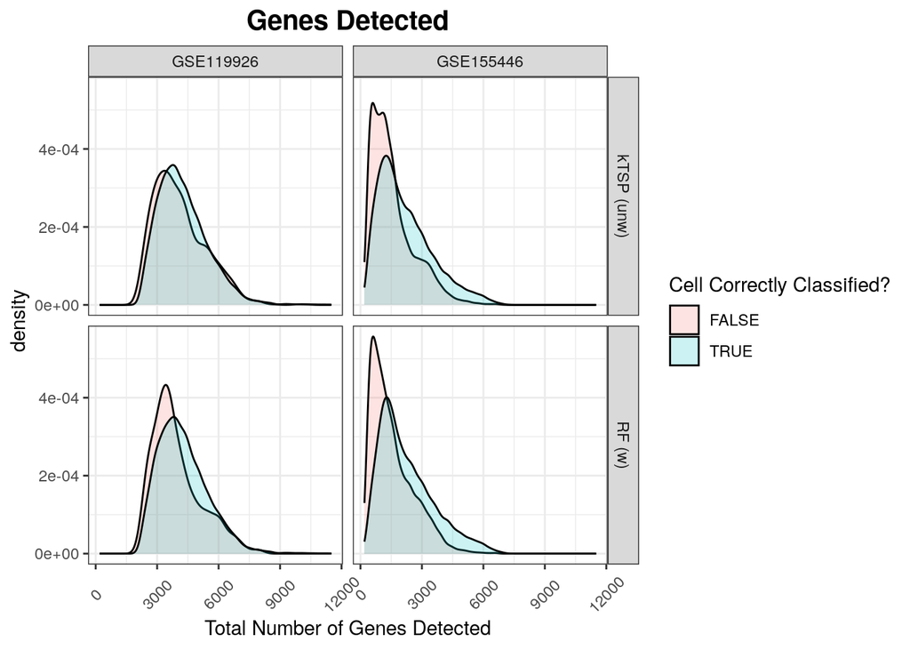

```r
num_genes_detected_df |>
  # Remove sample where it's impossible for predicted labels and the subgroup
  # to match, as the model cannot predict "G3/G4"
  dplyr::filter(subgroup %in% mb_subgroups) |>
  ggplot(aes(x = num_genes_detected,
             fill = correct_classification,
             group = correct_classification)) +
  geom_density(alpha = 0.2) +
  facet_grid(rows = vars(model_type), cols = vars(study)) +
  labs(x = "Total Number of Genes Detected",
       fill = "Cell Correctly Classified?",
       title = "Genes Detected") +
  theme_bw() +
  theme(axis.text.x = element_text(angle = 45, vjust = 0.5),
        plot.title = element_text(hjust = 0.5, size = 15, face = "bold"))
```

Cells that have predicted labels that are different from the sample’s true subgroup label appear to tend to have fewer total genes detected, particularly in the 10X experiment.

### Number of genes in model that are not detected

What about genes that are explicitly included in the model? How many of those are zero? Let’s consider each model separately.

#### Random Forest

```r
# Grab only the rows relevant to RF model
rf_df <- expression_df |>
  dplyr::filter(model_type == "RF (w)", model == "RF") |>
  # These columns are only relevant to the kTSP models
  dplyr::select(-gene_subgroup, -gene_in_pair)

# Count the number of genes in the model that are zero
rf_informative_genes_df <- rf_df |>
  dplyr::group_by(sample_accession,
                  cell_index) |>
  dplyr::summarize(num_zeros = sum(expression == 0)) |>
  dplyr::inner_join(
    num_genes_detected_df |>
      dplyr::filter(model_type != "kTSP (unw)") |>
      dplyr::select(sample_accession,
                    cell_index,
                    predicted_labels,
                    study,
                    correct_classification),
    by = c("sample_accession", "cell_index")
  )
```

Look at the number of zeros between correctly and incorrectly classified cells.

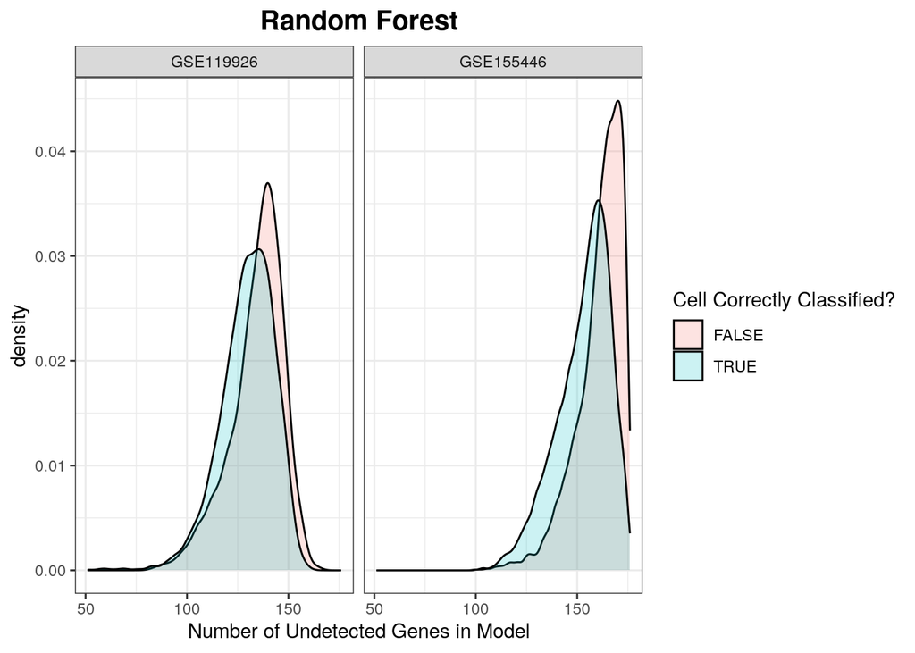

```r
rf_informative_genes_df |>
  ggplot(aes(x = num_zeros,
             fill = correct_classification,
             group = correct_classification)) +
  geom_density(alpha = 0.2) +
  facet_grid(cols = vars(study)) +
  labs(x = "Number of Undetected Genes in Model",
       fill = "Cell Correctly Classified?",
       title = "Random Forest") +
  theme_bw() +
  theme(plot.title = element_text(hjust = 0.5, size = 15, face = "bold"))
```

Let’s also look based on the predicted label.

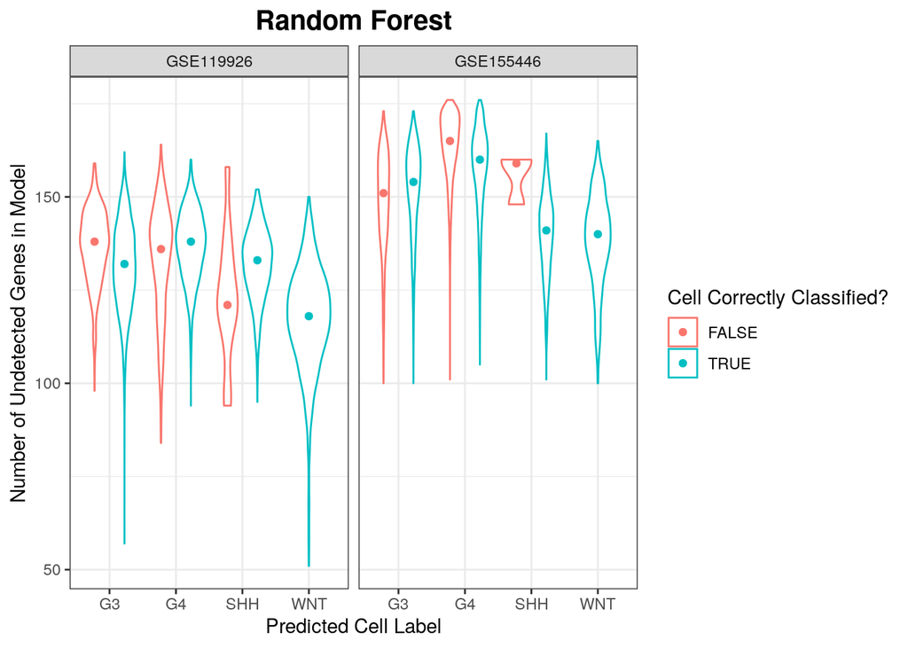

```r
rf_informative_genes_df |>
  ggplot(aes(x = predicted_labels,
             y = num_zeros,
             color = correct_classification)) +
  geom_violin(position = "dodge") +
  facet_grid(cols = vars(study)) +
  theme_bw() +
  labs(x = "Predicted Cell Label",
       y = "Number of Undetected Genes in Model",
       color = "Cell Correctly Classified?",
       title = "Random Forest") +
  stat_summary(fun = median,
               geom = "point",
               position = position_dodge(width = 0.9))  +
  theme(plot.title = element_text(hjust = 0.5, size = 15, face = "bold"))
```

This suggests that the cells getting incorrectly labeled as G4 tend to have 0s for many of the genes in the RF model in the 10X dataset.

#### k-Top Scoring Pairs

Let’s now look at the kTSP models. For kTSP models, we can identify which subgroup’s rules a gene is included in. Different subgroups will have differing numbers of rules and, therefore, different numbers of informative genes. Thus, it’s more helpful to look at the percentage of genes with a 0 count or TPM value on a per subgroup basis.

```r
# Grab only the rows relevant to kTSP model
ktsp_df <- expression_df |>
  dplyr::filter(model_type == "kTSP (unw)", model == "kTSP") |>
  # Drop the column that contains information about whether a gene is gene 1
  # or gene 2 in the rule
  dplyr::select(-gene_in_pair)

# Get the percentage of genes involved in each subgroup's rules that are
# zero
ktsp_informative_genes_df <- ktsp_df |>
  # Need the cell (sample_accession + cell_index) and which subgroup a gene
  # is informative about
  dplyr::group_by(sample_accession,
                  cell_index,
                  gene_subgroup) |>
  # Number genes expression == 0 / number of genes
  dplyr::summarize(percent_zeros = sum(expression == 0) / dplyr::n()) |>
  # Add information about the study, predicted labels, sample subgroup, and
  # whether or not a cell was correctly classified
  dplyr::inner_join(
    num_genes_detected_df |>
      dplyr::filter(model_type != "RF (w)") |>
      dplyr::select(sample_accession,
                    cell_index,
                    study,
                    predicted_labels,
                    subgroup,
                    correct_classification),
    by = c("sample_accession", "cell_index")
  ) |>
  # Only keep the rows with the gene subgroup relevant to the true subgroup
  dplyr::filter(gene_subgroup == subgroup)
```

[output not shown]

For each true subgroup label, compare the % of genes in the subgroup rules that are zero between correctly and incorrectly classified cells.

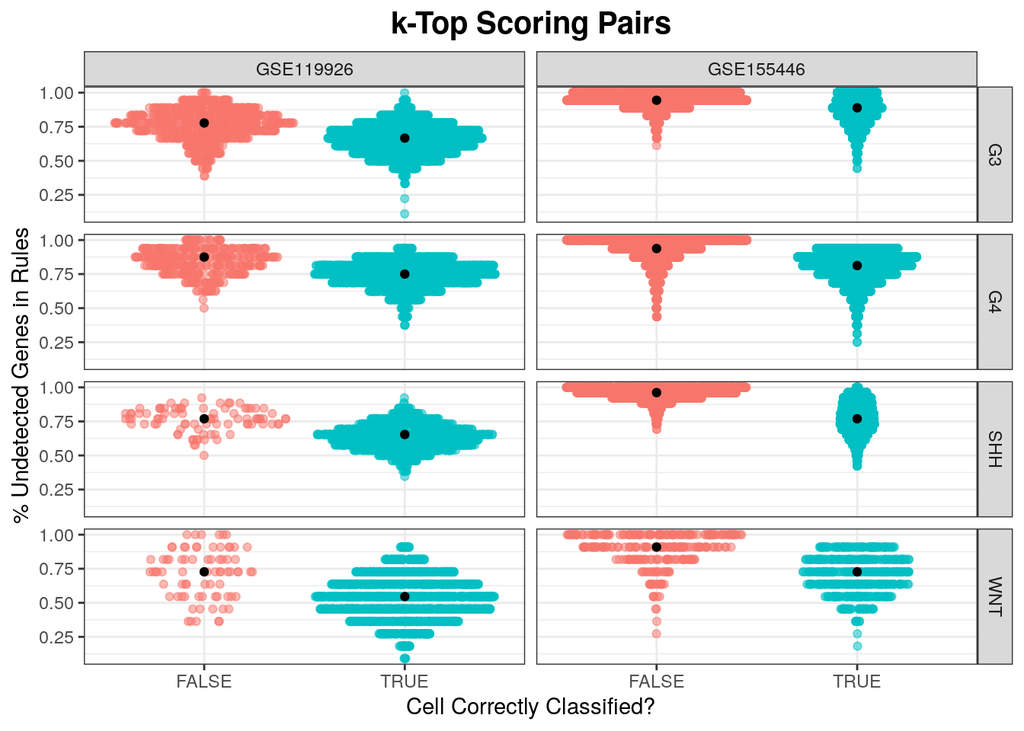

```r
ktsp_informative_genes_df |>
  # Remove genes that couldn't be classified correctly because the sample is
  # "G3/G4" which the model does not predict but make it more general
  dplyr::filter(subgroup %in% mb_subgroups) |>
  ggplot(aes(x = correct_classification,
             y = percent_zeros,
             color = correct_classification)) +
  ggforce::geom_sina(alpha = 0.5) +
  facet_grid(rows = vars(subgroup), cols = vars(study)) +
  guides(color = "none") +
  labs(x = "Cell Correctly Classified?",
       y = "% Undetected Genes in Rules",
       title = "k-Top Scoring Pairs") +
  stat_summary(fun = median,
               geom = "point",
               color = "black")  +
  theme_bw() +
  theme(plot.title = element_text(hjust = 0.5, size = 15, face = "bold"))
```

As we might expect, when a cell gets labeled as another subgroup, the genes in the true subgroup’s rules tend to have more zeros.

But there are some instances where cells are correctly classified without any genes in that group detected. What subgroups does this happen for?

```r
correctly_classified_with_all_zeros_df <- ktsp_informative_genes_df |>
  dplyr::filter(correct_classification, percent_zeros == 1)

correctly_classified_with_all_zeros_df |>
  dplyr::group_by(predicted_labels) |>
  dplyr::count()
```

| predicted_labels | n |
| --- | --- |
| G3 | 1474 |
| SHH | 16 |

A cell can be classified as G3 if all rules have a score of zero, which will sometimes happen to be correct:

```r
correctly_classified_with_all_zeros_df |>
  dplyr::select(sample_accession, cell_index) |>
  dplyr::left_join(dplyr::filter(single_cell_plot_df,
                                 model_type == "kTSP (unw)"),
                   by = c("sample_accession", "cell_index")) |>
  dplyr::filter(G3 == 0,
                G4 == 0,
                SHH == 0,
                WNT == 0) |>
  dplyr::group_by(predicted_labels) |>
  dplyr::count()
```

| predicted_labels | n |
| --- | --- |
| G3 | 1474 |

This explains **most cases** of correct cells with informative counts all = 0, most likely because G3 comes before all other subgroups alphabetically.

But there are some instances of SHH cells being correctly classified without informative gene counts as well. Let’s take a look at those:

```r
correctly_classified_with_all_zeros_df |>
  dplyr::select(sample_accession, cell_index) |>
  dplyr::left_join(dplyr::filter(single_cell_plot_df,
                                 model_type == "kTSP (unw)"),
                   by = c("sample_accession", "cell_index")) |>
  dplyr::filter(predicted_labels == "SHH") |>
  dplyr::pull(SHH) |>
  summary()
```

```
##    Min. 1st Qu.  Median    Mean 3rd Qu.    Max.
## 0.07206 0.07206 0.07206 0.07206 0.07206 0.07206
```

```
## Classes argument misses the following classes, they will be removed from the heatmap:
```

```
## WNT G4 G3
```

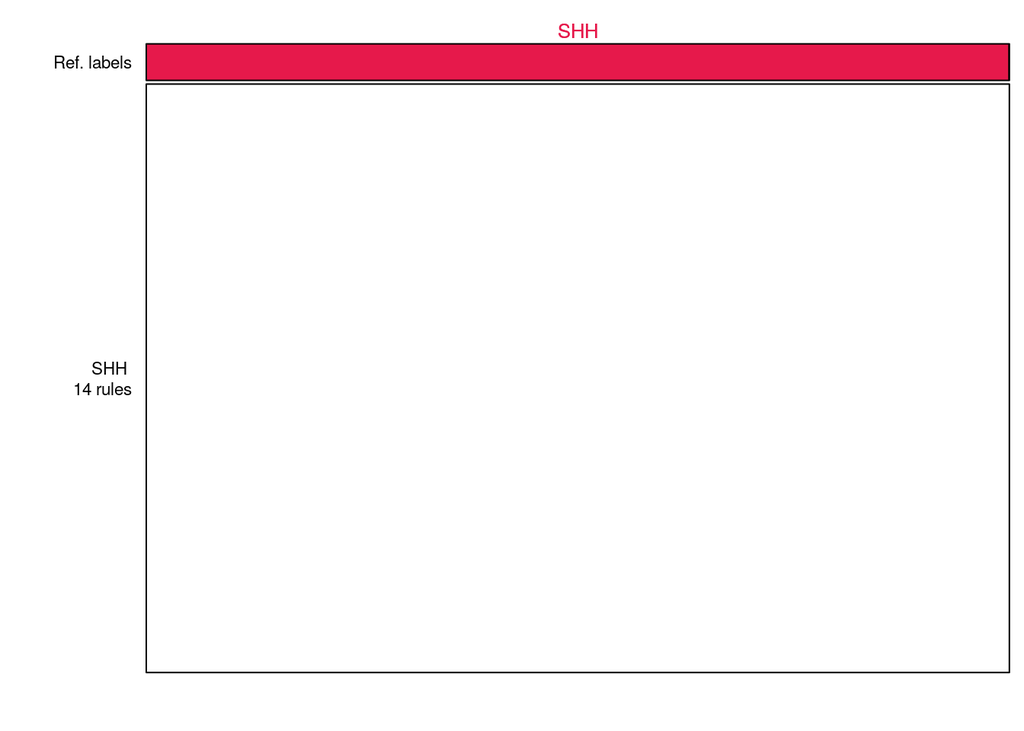

```r
# Get wide version of expression, only for relevant genes, i.e., in the kTSP models
exprs_shh_zeros <- correctly_classified_with_all_zeros_df |>
  dplyr::filter(predicted_labels == "SHH") |>
  dplyr::select(sample_accession, cell_index) |>
  dplyr::left_join(dplyr::filter(expression_df,
                                 model == "kTSP",
                                 model_type == "kTSP (unw)"),
                   by = c("sample_accession", "cell_index")) |>
  dplyr::select(sample_accession, cell_index, gene, expression) |>
  tidyr::pivot_wider(names_from = c(sample_accession, cell_index),
                     values_from = expression) |>
  tibble::column_to_rownames("gene")

# Prepare it for use with multiclassPairs
shh_zeros_mcp_data <- multiclassPairs::ReadData(Data = exprs_shh_zeros,
                                                Labels = rep("SHH",
                                                             ncol(exprs_shh_zeros)),
                                                Platform = rep("scRNA-seq",
                                                               ncol(exprs_shh_zeros)),
                                                verbose = FALSE)

# Make the binary TSP plot
multiclassPairs::plot_binary_TSP(Data = shh_zeros_mcp_data,
                                 classifier = ktsp_model,
                                 classes = "SHH",
                                 show_rule_name = TRUE,
                                 show_platform = FALSE,
                                 show_predictions = FALSE,
                                 cluster_cols = FALSE,
                                 cluster_rows = FALSE,
                                 legend = FALSE,
                                 anno_height = 0.05,
                                 score_height = 0.05,
                                 margin = c(0, 5, 0, 0.5))
```

This is not what I would expect based on the SHH scores, so further investigation is required.